# Soccer Ratings Backtest

Predictions vs Actuals — FanTeam Monster

04 February 2026

```
## [18:39:58] [INFO] get_fanteam_soccer_gameweeks() called
## [18:39:58] [DEBUG] Found files: week_18.csv, week_19_goalscorer_odds.csv, week_19_odds_report.csv, week_19_rotowire_projections.csv, week_19.csv, week_20_goalscorer_odds.csv, week_20_odds_report.csv, week_20.csv, week_21_goalscorer_odds.csv, week_21_odds_report.csv, week_21.csv, week_22_goalscore…
## [18:39:58] [INFO] Available gameweeks: 25, 24, 23, 22, 21, 20, 19, 18
```

```
## [18:39:58] [INFO] load_fanteam_stats_overview() called
## [18:39:58] [INFO] Loaded 530 rows from cache: ft_overview
```

```
## [18:39:58] [INFO] load_fanteam_stats_detail() called
## [18:39:58] [INFO] Loaded 11722 rows from cache: ft_detail
```

[output not shown]

[output not shown]

[output cut: 241 more lines]

[output not shown]

## Overview

8

Gameweeks  
with salaries

5

Gameweeks  
with actuals

3,807

Player-GW  
records

2,224

With actual  
points

Actuals available for GW: **18, 19, 20, 21, 22**. Stats overview has **530** players. Detail data covers **22** gameweeks.

2,494 **picked_by** values detected (66% of records). ✅ Using as primary ownership signal.

## PPG Prediction Accuracy

How well does our projected PPG (season average) predict this week’s actual points?

1.6

MAE

2.2

RMSE

-0.2

Mean Bias

0.385

Correlation

A PPG correlation of **0.385** means our season averages explain about **15%** of the variance in weekly scores. Football is inherently noisy — correlations above 0.20 are useful, above 0.30 is strong.

### Scatter: Predicted vs Actual

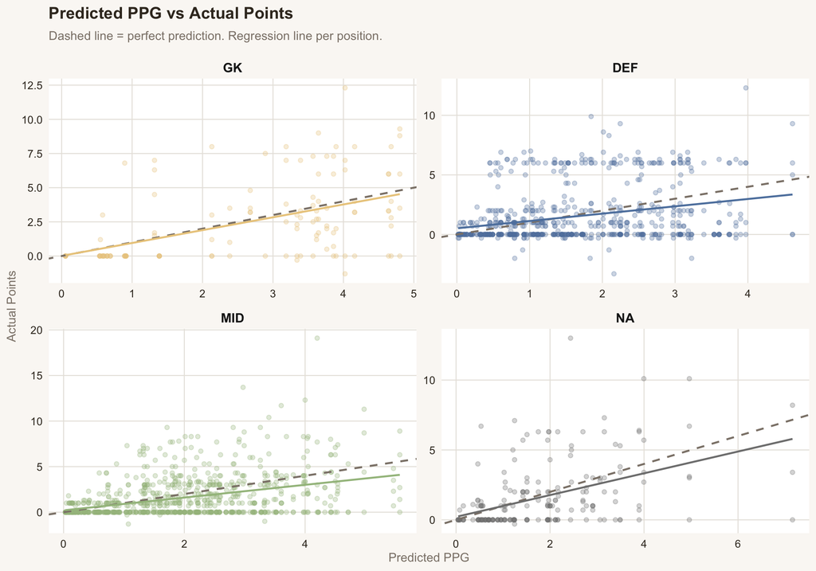

### By Position

PPG prediction accuracy by position

| Position | N | Avg Predicted | Avg Actual | MAE | Correlation |
| --- | --- | --- | --- | --- | --- |
| DEF | 708 | 1.6 | 1.5 | 1.7 | 0.29 |
| FOR | 206 | 1.8 | 1.6 | 1.5 | 0.45 |
| GK | 125 | 2.6 | 2.5 | 1.9 | 0.49 |
| MID | 869 | 1.9 | 1.5 | 1.5 | 0.40 |

### By Gameweek

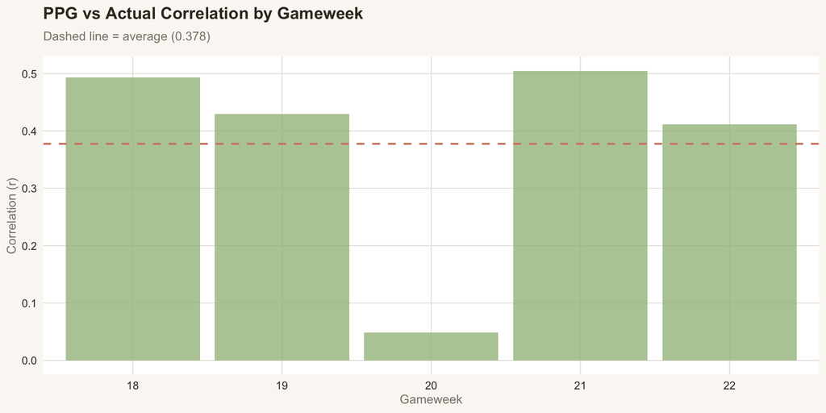

## Cash Rating Analysis

Do Cash Locks actually outscore Hard Passes?

Tier ordering is **monotonic ✅**. Cash Locks outscore each lower tier on average — the signal works.

### Distribution by Tier

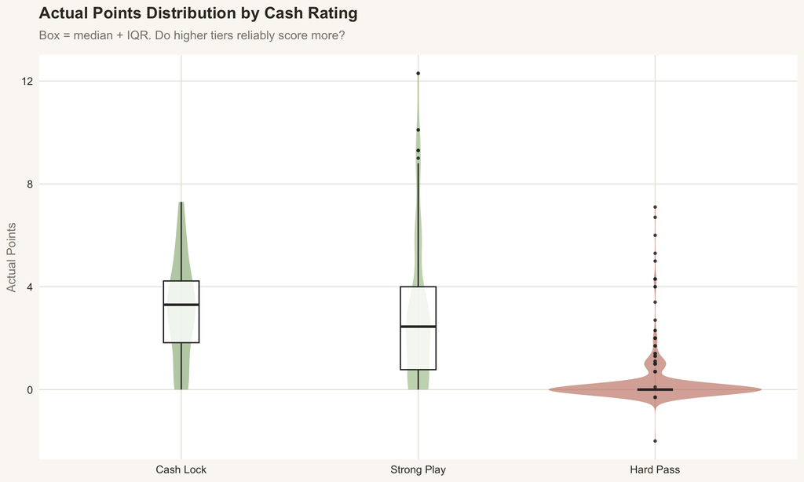

### Cash Score Correlation

0.372

Cash Score vs  
Actual Points

## GPP Rating Analysis

Do Smash Plays deliver tournament-winning ceilings?

GPP tier performance — p90 and max matter most here

| Rating | N | Avg Actual | p90 Actual | Max Actual | Avg GPP Score |
| --- | --- | --- | --- | --- | --- |
| Smash Play | 6 | 2.8 | 5.8 | 8 | 86 |
| Leverage Gold | 292 | 2.4 | 6.6 | 14 | 75 |
| Sneaky Good | 603 | 2.0 | 6.0 | 19 | 62 |
| Meh | 632 | 1.4 | 5.0 | 10 | 48 |
| Chalk Trap | 375 | 0.4 | 1.1 | 6 | 33 |
| Dead Money | 316 | 0.1 | 0.0 | 7 | 17 |

### Ceiling Outcomes by Tier

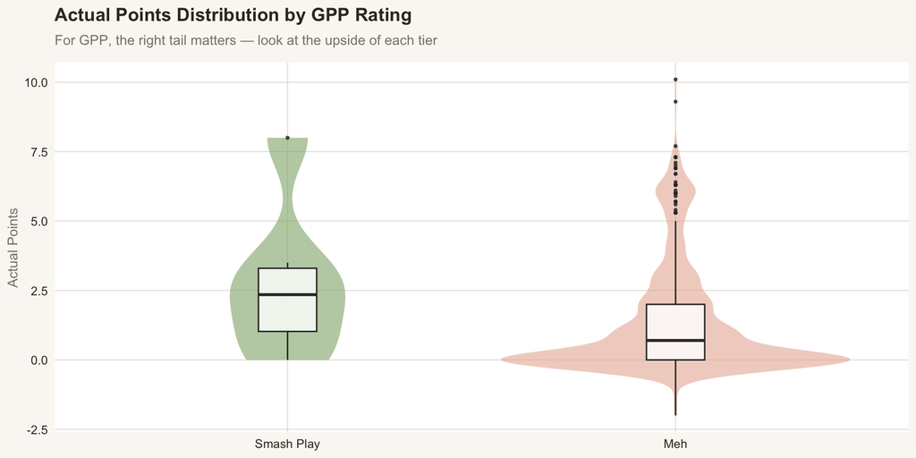

## Matchup Quality Signal

Does our matchup quality score (0–100) predict actual points?

Quintile 5 = best matchups. Does MQ predict scoring?

| MQ Quintile | N | Avg MQ | Avg Actual Pts | Avg Predicted |
| --- | --- | --- | --- | --- |
| 1 | 445 | 35.1 | 1.2 | 1.3 |
| 2 | 445 | 46.3 | 1.2 | 1.6 |
| 3 | 445 | 50.0 | 1.5 | 1.5 |
| 4 | 445 | 54.6 | 1.3 | 1.5 |
| 5 | 444 | 64.7 | 1.5 | 1.8 |

### By Position

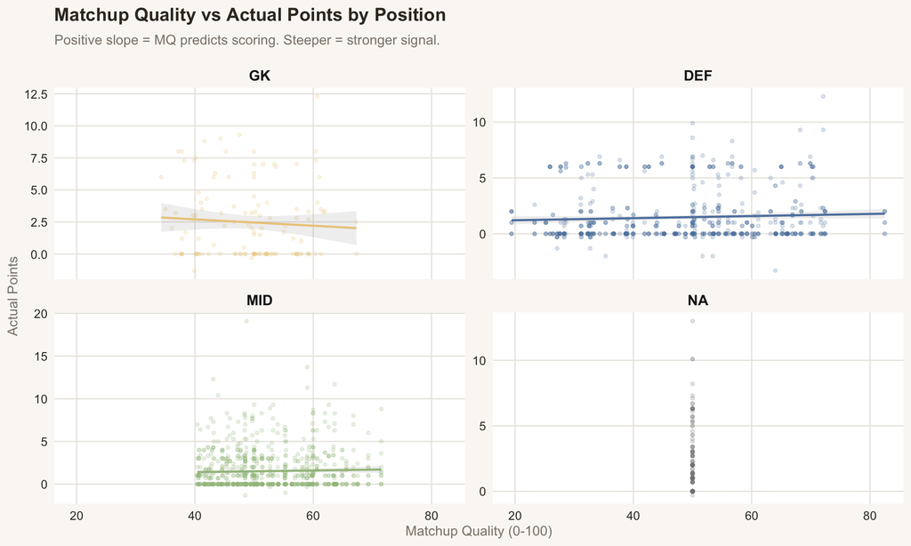

Overall MQ correlation: **0.039**. By position: DEF=0.049, FOR=NA, FWD=NA, GK=-0.008, MID=0.032. MQ signal is typically weak at the player level (0.05–0.15) because individual variance dominates team context.

## Floor / Ceiling Calibration

Are our floor (2nd worst score) and ceiling (2nd best score) estimates realistic?

13.7%

Below Floor

82.3%

In Range

4%

Above Ceiling

### By Position

| Position | N | % Below Floor | % In Range | % Above Ceil | Avg Floor | Avg Ceil |
| --- | --- | --- | --- | --- | --- | --- |
| DEF | 4 | 0.0 | 100 | 0.0 | 0.5 | 7.4 |
| FOR | 25 | 12.0 | 88 | 0.0 | 0.9 | 9.5 |
| GK | 30 | 16.7 | 80 | 3.3 | 1.0 | 8.1 |
| MID | 65 | 13.8 | 80 | 6.2 | 1.2 | 7.2 |

## Ownership Estimation

5.0

MAE (%pts)

0.667

Correlation

+1.0

Mean Bias

### Predicted vs Actual Ownership

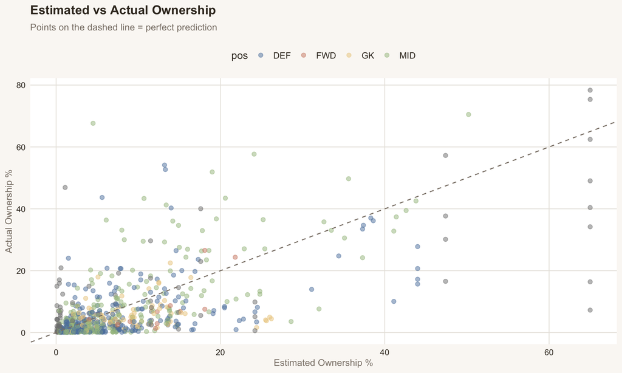

### Worst Misses

15 largest ownership estimation errors

| GW | Player | Pos | Salary | Est Own% | Actual Own% | Error | Picked By | Cash |
| --- | --- | --- | --- | --- | --- | --- | --- | --- |
| 20 | Gabriel Martinelli | MID | 11.9 | 4.5 | 67.65 | 63.2 | 1.1 | Playable |
| 20 | Igor Thiago | FOR | 8.3 | 65.0 | 7.26 | 57.7 | 50.2 | Strong Play |
| 24 | Igor Thiago | FOR | 8.8 | 65.0 | 16.40 | 48.6 | 50.2 | Solid |
| 23 | Omar Marmoush | FOR | 14.4 | 1.1 | 46.90 | 45.8 | 1.3 | Hard Pass |
| 23 | Marc Guehi | DEF | 6.0 | 13.2 | 54.15 | 41.0 | 13.2 | Solid |
| 22 | Jeremie Frimpong | DEF | 11.7 | 13.3 | 52.71 | 39.4 | 11.6 | Solid |
| 21 | Keane Lewis-Potter | DEF | 10.1 | 5.6 | 43.67 | 38.1 | NA | Playable |
| 20 | Jarrod Bowen | MID | 9.0 | 24.1 | 57.69 | 33.6 | 27.5 | Strong Play |
| 24 | Bruno Fernandes | MID | 13.9 | 19.0 | 51.91 | 32.9 | 13.7 | Solid |
| 23 | Kevin Schade | MID | 10.3 | 10.7 | 43.35 | 32.7 | 8.1 | Solid |
| 21 | Jurrien Timber | DEF | 10.9 | 41.1 | 10.07 | 31.0 | 44 | Solid |
| 24 | Hugo Ekitike | FOR | 12.1 | 47.4 | 16.56 | 30.8 | 34.7 | Playable |
| 22 | Igor Thiago | FOR | 6.6 | 65.0 | 34.19 | 30.8 | 50.2 | Strong Play |
| 23 | Moises Caicedo | MID | 10.8 | 6.1 | 36.36 | 30.3 | 2.7 | Playable |
| 23 | Jurrien Timber | DEF | 10.6 | 44.0 | 15.68 | 28.3 | 44 | Strong Play |

### Spot Check (Latest GW)

Top 20 predicted ownership — GW 25 (compare against actual contest results)

| Player | Pos | Team | Salary | Est Own% | Est Cpt% | Picked By | Cash | MQ |
| --- | --- | --- | --- | --- | --- | --- | --- | --- |
| Erling Haaland | FOR | Manchester City | 11.1 | 65.0 | 0.0 | 77.1 | Strong Play | 50.0 |
| Jurrien Timber | DEF | Arsenal | 12.3 | 65.0 | 0.1 | 44 | Strong Play | 71.7 |
| Igor Thiago | FOR | Brentford | 8.8 | 65.0 | 0.0 | 50.2 | Solid | 50.0 |
| Gabriel Magalhaes | DEF | Arsenal | 12.2 | 55.9 | 0.0 | 35.8 | Strong Play | 71.7 |
| Hugo Ekitike | FOR | Liverpool | 10.6 | 47.4 | 0.0 | 34.7 | Playable | 50.0 |
| Bukayo Saka | MID | Arsenal | 14.7 | 43.3 | 31.9 | 41.8 | Solid | 59.9 |
| Phil Foden | MID | Manchester City | 10.0 | 35.5 | 23.3 | 38.7 | Solid | 59.9 |
| Morgan Rogers | MID | Aston Villa | 10.4 | 35.1 | 14.6 | 36.9 | Cash Lock | 55.2 |
| Antoine Semenyo | MID | Manchester City | 10.5 | 34.3 | 12.3 | 34.9 | Solid | 59.9 |
| David Raya | GK | Arsenal | 12.5 | 27.3 | 0.0 | 27.6 | Cash Lock | 62.0 |
| Jarrod Bowen | MID | West Ham | 10.3 | 26.2 | 2.0 | 27.5 | Strong Play | 48.5 |
| Pablo Pablo | FWD | West Ham | 9.5 | 25.6 | 0.4 | NA | Playable | 49.6 |
| Joao Pedro | FOR | Chelsea | 12.7 | 24.2 | 0.0 | 17.7 | Solid | 50.0 |
| Bruno Guimaraes | MID | Newcastle United | 12.1 | 23.7 | 0.8 | 20.7 | Solid | 49.5 |
| Virgil van Dijk | DEF | Liverpool | 6.7 | 23.2 | 0.0 | 26.2 | Solid | 54.3 |
| Marc Cucurella | DEF | Chelsea | 10.1 | 22.6 | 0.0 | 20.3 | Solid | 58.4 |
| Tammy Abraham | FWD | Aston Villa | 9.3 | 21.8 | 0.3 | NA | Playable | 56.6 |
| Declan Rice | MID | Arsenal | 14.0 | 20.6 | 0.4 | 15.8 | Solid | 59.9 |
| Enzo Fernandez | MID | Chelsea | 12.4 | 19.0 | 0.3 | 13.5 | Solid | 65.6 |
| Evanilson Evanilson | FWD | Bournemouth | 9.2 | 18.1 | 0.2 | NA | Playable | 53.6 |

## Picked By Signal

How predictive is the FanTeam season-long `picked_by` statistic?

0.241

picked_by vs  
Actual Points

0.611

picked_by vs  
Season PPG

1,560

Players with  
picked_by > 0

`picked_by` vs actual weekly points (r=0.241) is the **weekly signal** — moderate because it is a season-long stat. picked_by vs PPG (r=0.611) shows how well it tracks season averages — this should be high.

### Picked By Deciles vs Actual Points

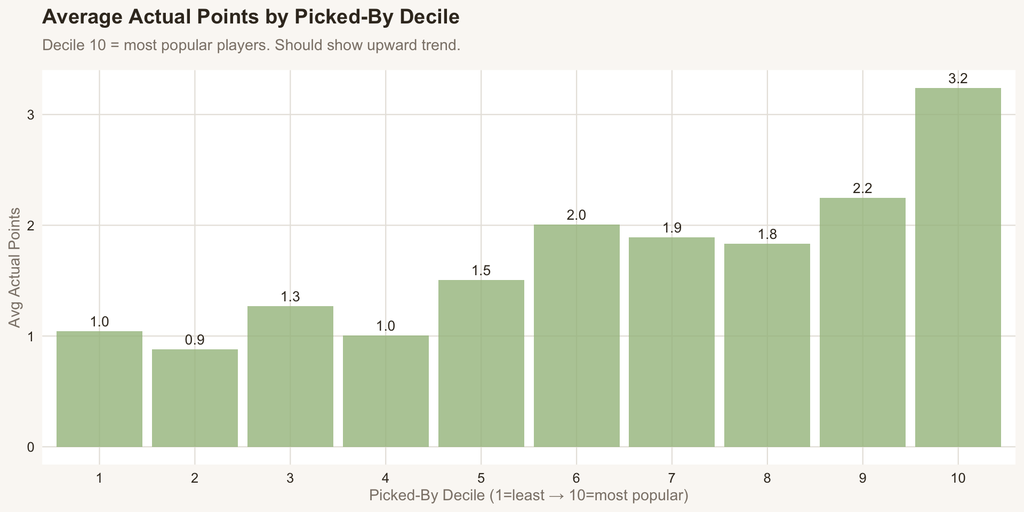

## Biggest Misses

### Cash Locks That Bombed

Players rated as Cash Lock who scored poorly — where is the model overconfident?

Cash Locks with lowest actual points

| GW | Player | Pos | Salary | Cash Score | Actual Pts | PPG | MQ | Est Own% |
| --- | --- | --- | --- | --- | --- | --- | --- | --- |
| 20 | Bernardo Silva | MID | 11.7 | 85.3 | 0.0 | 2.54 | 63.9 | 5.4 |
| 20 | David Raya | GK | 10.7 | 91.8 | 0.0 | 4.64 | 57.7 | 25.6 |
| 20 | Guglielmo Vicario | GK | 10.4 | 89.0 | 0.0 | 3.86 | 59.2 | 9.5 |
| 18 | John McGinn | MID | 6.7 | 86.7 | 0.7 | 3.32 | 55.2 | 2.6 |
| 19 | Pedro Neto | MID | 13.7 | 92.4 | 1.0 | 4.33 | 66.8 | 12.6 |
| 22 | Guglielmo Vicario | GK | 10.5 | 85.2 | 1.7 | 3.86 | 55.0 | 9.4 |
| 18 | Bart Verbruggen | GK | 4.9 | 92.2 | 2.2 | 3.76 | 55.2 | 11.1 |
| 18 | Morgan Rogers | MID | 7.5 | 91.3 | 2.3 | 5.46 | 55.2 | 32.3 |
| 21 | Pedro Neto | MID | 11.0 | 91.2 | 2.7 | 4.33 | 56.9 | 9.3 |
| 18 | Pedro Neto | MID | 12.3 | 94.2 | 2.7 | 4.33 | 65.6 | 12.6 |
| 19 | David Raya | GK | 11.8 | 94.0 | 3.3 | 4.64 | 61.7 | 21.2 |
| 18 | David Raya | GK | 11.2 | 93.0 | 3.3 | 4.64 | 62.0 | 26.2 |
| 21 | James Garner | MID | 11.0 | 87.7 | 3.4 | 4.00 | 55.3 | 7.2 |
| 22 | Morgan Rogers | MID | 11.9 | 87.9 | 3.5 | 5.46 | 57.4 | 35.6 |
| 21 | Jordan Pickford | GK | 11.6 | 87.4 | 3.5 | 4.80 | 57.2 | 11.6 |

### Hard Passes That Exploded

Players rated as Hard Pass who massively outperformed — where are we missing value?

Hard Passes with highest actual points

| GW | Player | Pos | Salary | Cash Score | Actual Pts | PPG | MQ | Est Own% |
| --- | --- | --- | --- | --- | --- | --- | --- | --- |
| 21 | Liam Delap | FOR | 9.4 | 22.6 | 7.1 | 1.25 | 50.0 | 0.4 |
| 19 | Yoane Wissa | FOR | 10.9 | 8.4 | 6.7 | 0.53 | 50.0 | 0.6 |
| 19 | Dennis Cirkin | DEF | 4.4 | 24.1 | 6.0 | 0.45 | 25.9 | 0.6 |
| 18 | Kevin Danso | DEF | 5.6 | 23.6 | 5.3 | 0.75 | 32.3 | 0.7 |
| 19 | Joshua Zirkzee | FOR | 13.1 | 21.6 | 5.0 | 1.21 | 50.0 | 0.2 |
| 22 | Liam Delap | FOR | 12.1 | 23.8 | 4.3 | 1.25 | 50.0 | 0.4 |
| 22 | Merlin Rohl | MID | 4.8 | 22.4 | 4.3 | 0.71 | 42.2 | 0.4 |
| 19 | Tyler Dibling | MID | 6.2 | 18.5 | 4.3 | 0.59 | 43.1 | 1.2 |
| 19 | Merlin Rohl | MID | 5.9 | 22.3 | 4.3 | 0.71 | 43.1 | 0.5 |
| 21 | Bashir Humphreys | DEF | 4.4 | 18.2 | 4.0 | 0.56 | 33.3 | 0.5 |
| 19 | Gabriel Jesus | FOR | 10.8 | 6.9 | 4.0 | 0.46 | 50.0 | 0.1 |
| 19 | Eliezer Mayenda | FOR | 5.1 | 22.4 | 3.4 | 1.02 | 50.0 | 2.4 |
| 22 | Randal Kolo Muani | FOR | 11.9 | 23.2 | 2.7 | 1.05 | 50.0 | 0.3 |
| 21 | Issa Diop | DEF | 5.9 | 22.4 | 2.3 | 0.28 | 36.5 | 0.6 |
| 18 | Randal Kolo Muani | FOR | 7.0 | 22.6 | 2.3 | 1.05 | 50.0 | 0.3 |

### GPP Fades That Smashed

Fades with highest actual points — GPP upside we’re missing

[output not shown]

## Data Export

Full results exported to `data/backtest_results.csv` — **3,807 rows** across **8 gameweeks**. Open in Excel or R for deeper analysis.

Generated 04 Feb 2026 at 18:40 · Soccer Ratings Backtester v1.0